# Goal 3 Multivariate: US

Jaclyn A Coate

7/28/2020

# US COVID Data

## Data Prep

```r
us <- read.csv("https://raw.githubusercontent.com/JaclynCoate/6373_Time_Series/master/TermProject/Data/USdaily.7.26.20.csv", header = T, strip.white = T)
us <- transform(us, date = as.Date(as.character(date), "%Y%m%d"))
us <- subset(us, select = -c(states, dateChecked, hospitalized, lastModified, total, posNeg, totalTestResultsIncrease, hash))
us[is.na(us)] <- 0
#Selecting only those dates with reported current hospitilizations
#us <- dplyr::slice(us,1:132)
us = us[order(as.Date(us$date, format = "%Y%m%d")),]
head(us)
```

```
##           date positive negative pending hospitalizedCurrently
## 187 2020-01-22        2        0       0                     0
## 186 2020-01-23        2        0       0                     0
## 185 2020-01-24        2        0       0                     0
## 184 2020-01-25        2        0       0                     0
## 183 2020-01-26        2        0       0                     0
## 182 2020-01-27        2        0       0                     0
##     hospitalizedCumulative inIcuCurrently inIcuCumulative
## 187                      0              0               0
## 186                      0              0               0
## 185                      0              0               0
## 184                      0              0               0
## 183                      0              0               0
## 182                      0              0               0
##     onVentilatorCurrently onVentilatorCumulative recovered death
```

[output cut: 20 more lines]

### Current Hospitalization Realization

Traits:

- Heavy wandering behavior
- What appears to be some noise that could be pseudo-cyclic behavior hidden by the large numbers.

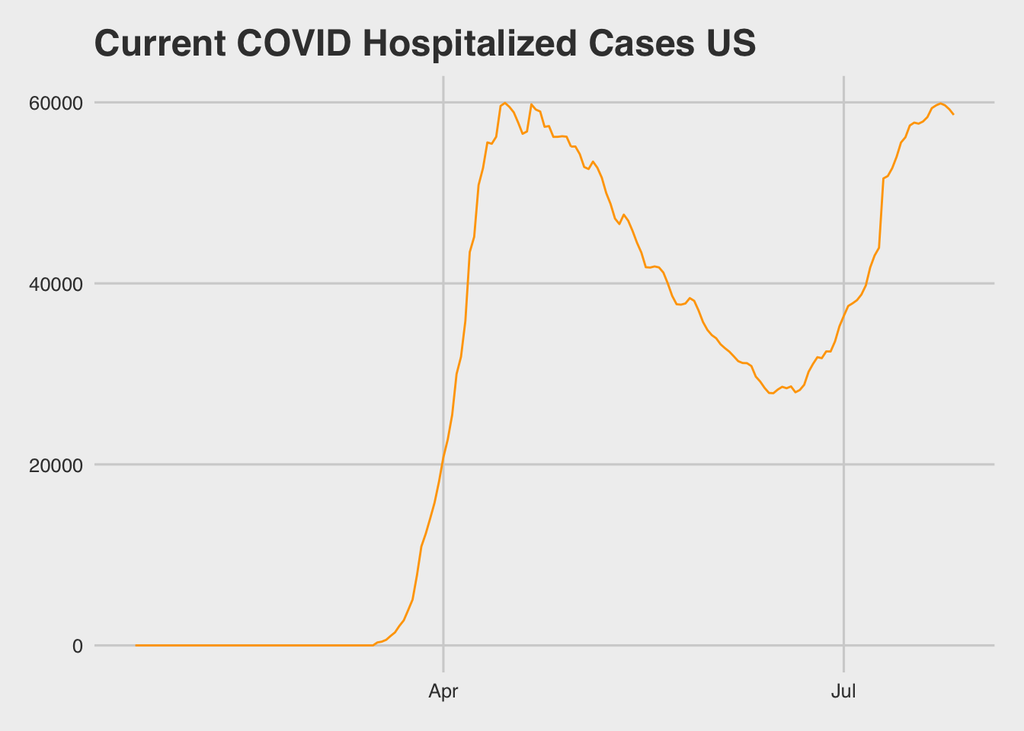

```r
ggplot(data = us, aes(x=date, y=hospitalizedCurrently))+
  geom_line(color="orange")+
  labs(title = "Current COVID Hospitalized Cases US", y = "Thousands", x = "") +
    theme_fivethirtyeight()
```

## Stationarity

It is difficult to assume stationarity for this data due to multiple factors. We are working under the assumption that COVID is a novel virus and cases as well as hospitalizations will eventually return to zero. This being said our current modeling techniques do things such as return to the median or mimic the previously seen trends. Also, we see a heavy wandering trend in both new cases and hospitalization would be dependent on this as well as time. We will review the data and see what, if any, non-stationary components reveal themselves and model the data accordingly.

## Forecast Current Hospitalizations

It is difficult to assume stationarity for this data due to multiple factors. We are working under the assumption that COVID is a novel virus and cases as well as hospitalizations will eventually return to zero. This being said our current modeling techniques do things such as return to the median or mimic the previously seen trends. Also, we see a heavy wandering trend in both new cases and hospitalization would be dependent on this as well as time. We will review the data and see what, if any, non-stationary components reveal themselves and model the data accordingly.

## Variable Review

When reviewing the variables and the scatter plot from our previous EDA we can see that there are some correlations that were expected, for example *currentHospitalizations* is correlated with the variables that refelct ICU and Ventilaor patients. These metrics wouldn’t exist without hospitalizations. These variables also cannot help up predict hospitalizations because they after occurances. So we will actually be leveraing variables such as *positive* and *positive increase* in order to see if there is some sort of correlation between hospitalized patients and the number of positive cases.

- Positive Tests Trend

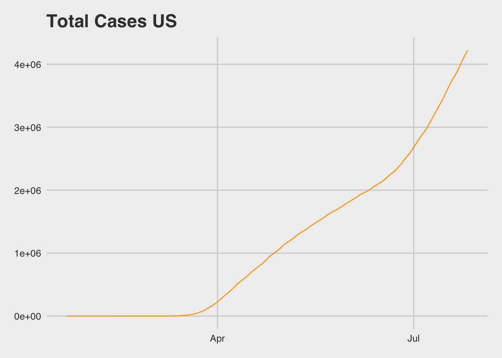

```r
ggplot(data = us, aes(x=date, y=positive))+
  geom_line(color="orange")+
  labs(title = "Total Cases US", y = "Millions", x = "") +
    theme_fivethirtyeight()
```

- Positive Increase Trend

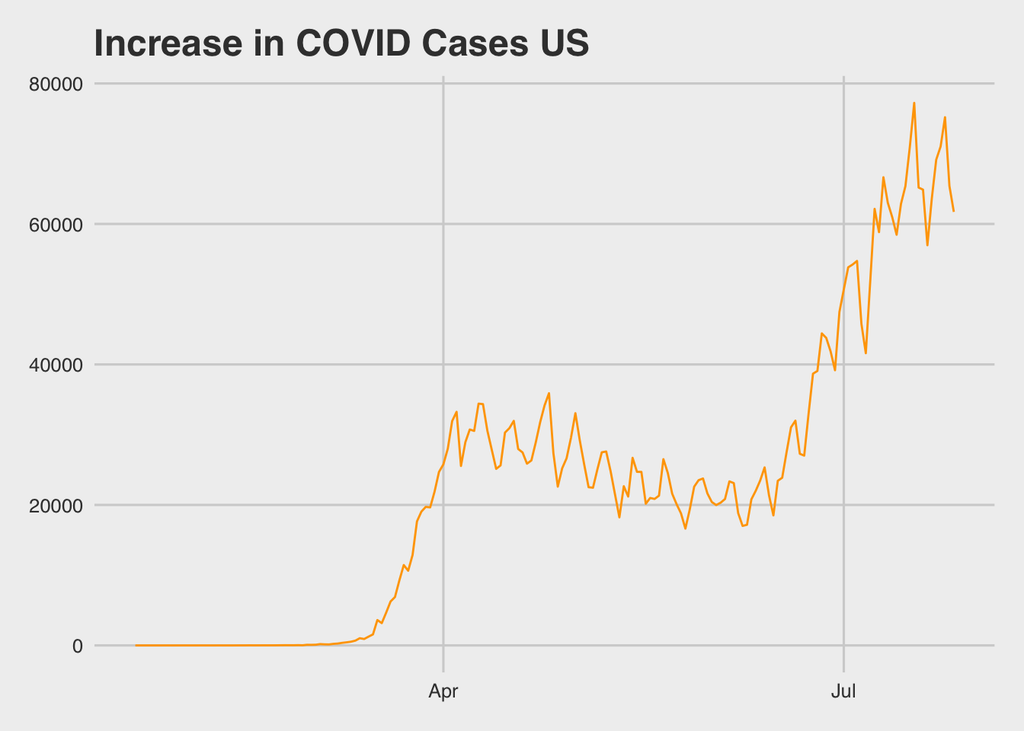

```r
ggplot(data = us, aes(x=date, y=positiveIncrease))+
  geom_line(color="orange")+
  labs(title = "Increase in COVID Cases US", y = "Thousands", x = "") +
    theme_fivethirtyeight()
```

### MLR w/ Correlated Errors for Currently Hospitalized Patients

#### Forecast Independent Variables

1. Forecast COVID Cases
   1. Evaluation: Heavy wandering, frequency peak at 0, and slowly dampening ACF consistend with (1-B) component

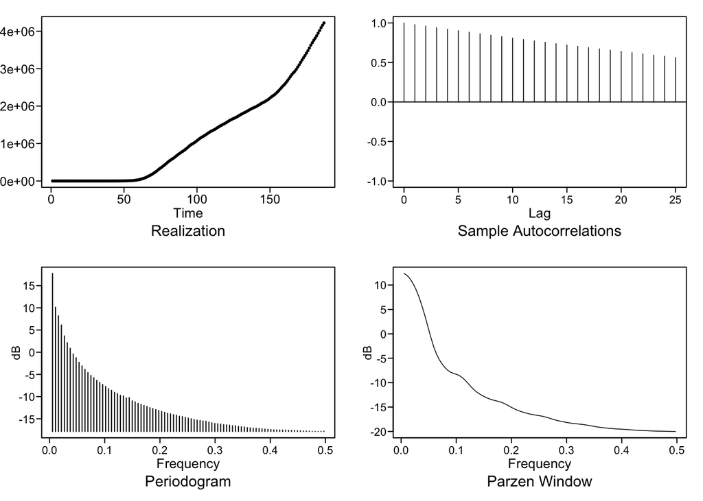

```
## $autplt
##  [1] 1.0000000 0.9802449 0.9605622 0.9410048 0.9216948 0.9025967 0.8836977
##  [8] 0.8649429 0.8462650 0.8277641 0.8094575 0.7914950 0.7738194 0.7563783
## [15] 0.7391523 0.7221011 0.7052654 0.6886822 0.6724063 0.6563621 0.6405962
## [22] 0.6250004 0.6094678 0.5940546 0.5788727 0.5639282
##
## $freq
##  [1] 0.005347594 0.010695187 0.016042781 0.021390374 0.026737968
##  [6] 0.032085561 0.037433155 0.042780749 0.048128342 0.053475936
## [11] 0.058823529 0.064171123 0.069518717 0.074866310 0.080213904
## [16] 0.085561497 0.090909091 0.096256684 0.101604278 0.106951872
## [21] 0.112299465 0.117647059 0.122994652 0.128342246 0.133689840
## [26] 0.139037433 0.144385027 0.149732620 0.155080214 0.160427807
## [31] 0.165775401 0.171122995 0.176470588 0.181818182 0.187165775
## [36] 0.192513369 0.197860963 0.203208556 0.208556150 0.213903743
```

[output cut: 53 more lines]

```
b. Differencing Data: still observe a slowly dampening ACF, secondary (1-B) transformation
```

```r
#a
plotts.sample.wge(us$positive)
```

```r
#b
pos.diff = artrans.wge(us$positive, phi.tr = 1, lag.max = 100)
```

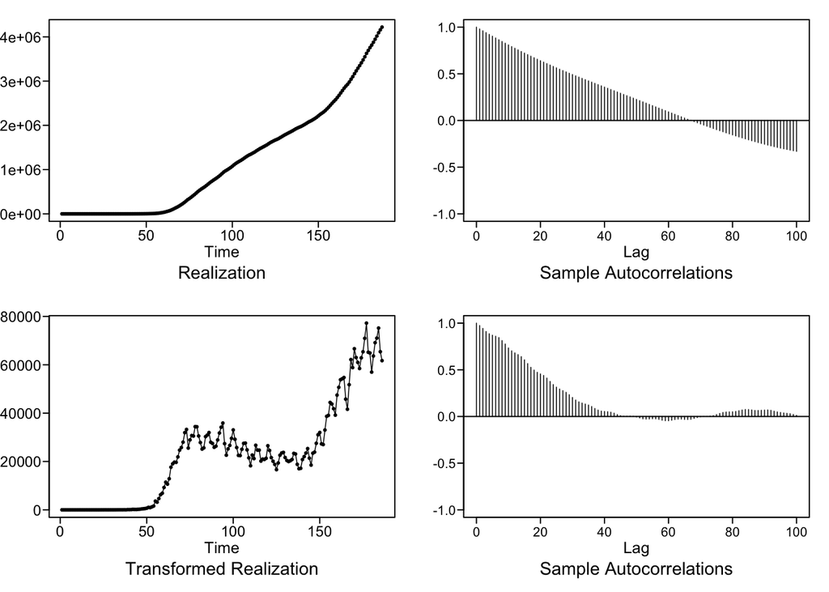

c. Differencing Data: much more stationary data and have surfaced a seasonaly component = 7 seen on ACF peaks at 7, 14, 21

```r
#c
pos.diff.2 = artrans.wge(pos.diff, phi.tr = 1, lag.max = 100)
```

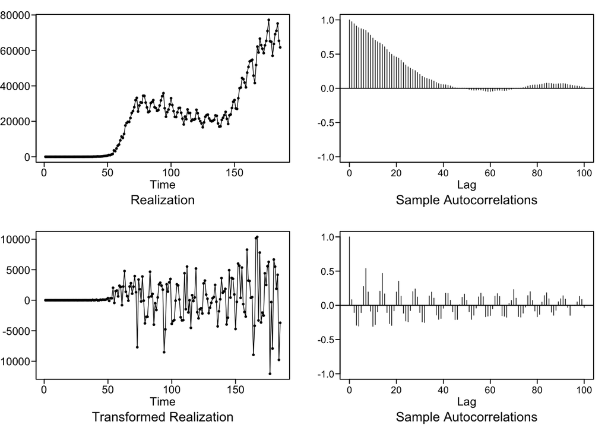

d. Seaonality Transformation: stationary data, and an ACF that reflects data other than whitenoise to be modeled.

```r
#d
pos.diff.seas = artrans.wge(pos.diff.2,phi.tr = c(0,0,0,0,0,0,1), lag.max = 100)
```

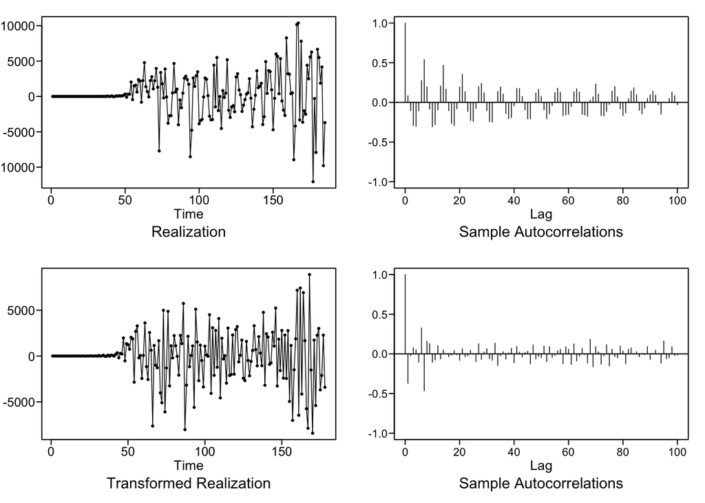

e. Model IDing: diagnose with aic.wge to determine phi, thetas: Both AIC/BIC select ARMA(4,2)

```r
#e
aic5.wge(pos.diff.seas)
```

```
## ---------WORKING... PLEASE WAIT...
##
##
## Five Smallest Values of  aic
```

```
##       p    q        aic
## 15    4    2   15.62972
## 9     2    2   15.75292
## 18    5    2   15.75381
## 12    3    2   15.75949
## 7     2    0   15.76130
```

```r
aic5.wge(pos.diff.seas, type = "bic")
```

```
## ---------WORKING... PLEASE WAIT...
##
##
## Five Smallest Values of  bic
```

```
##       p    q        bic
## 15    4    2   15.75485
## 2     0    1   15.79787
## 7     2    0   15.81493
## 4     1    0   15.82044
## 3     0    2   15.82122
```

```
f. White Noise Test: Reject the H_null and accept this data is not white noise
```

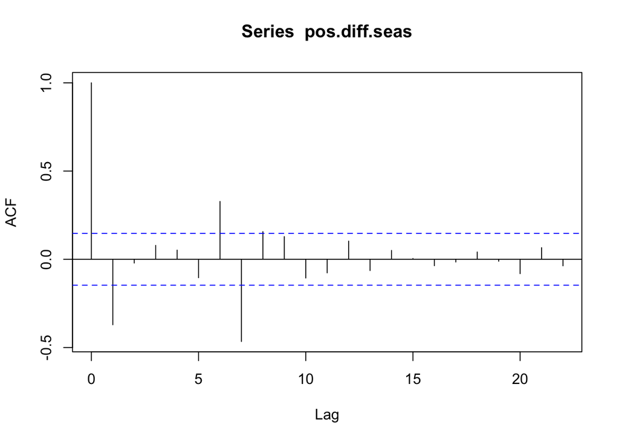

```r
#f
acf(pos.diff.seas)
```

```r
ljung.wge(pos.diff.seas)$pval
```

```
## Obs -0.3711871 -0.02127298 0.07854863 0.05194626 -0.1044837 0.3276797 -0.4658846 0.1565308 0.1284193 -0.1060784 -0.07693315 0.103073 -0.06391544 0.05002948 0.004471733 -0.03640371 -0.01551969 0.04133791 -0.0111003 -0.08153887 0.06570589 -0.03709668 -0.02390002 0.04588505
```

```
## [1] 1.568856e-12
```

```r
#ljung.wge(pos.diff.seas, K = 48)$pval
```

```
g. Estiamte Phis, Thetas:
```

```r
#g
est.pos.seas = est.arma.wge(pos.diff.seas, p = 4, q = 2)
```

```
##
## Coefficients of Original polynomial:
## -1.8726 -1.4973 -0.4734 0.0283
##
## Factor                 Roots                Abs Recip    System Freq
## 1+1.1292B+0.6983B^2   -0.8086+-0.8822i      0.8356       0.3681
## 1+0.7944B             -1.2588               0.7944       0.5000
## 1-0.0510B              19.6081               0.0510       0.0000
##
##
```

```r
mean(us$positive)
```

```
## [1] 1175047
```

```
h. Model Building
i. Forecast 7/90 Days
```

```r
#h
#Equation building
#i
pos.preds7 = fore.aruma.wge(us$positive, phi = est.pos.seas$phi, theta = est.pos.seas$theta, d=2, s=7, n.ahead = 7)
```

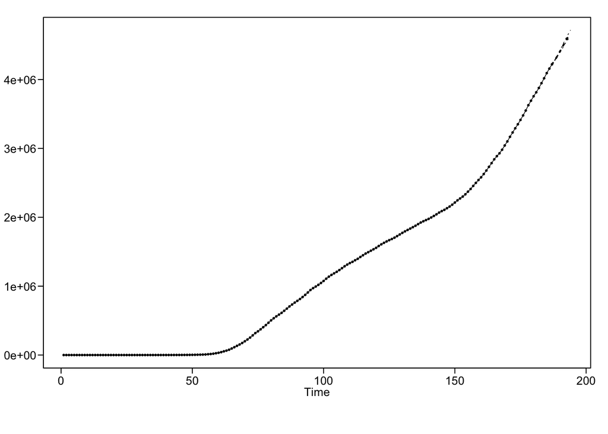

```r
pos.preds90 = fore.aruma.wge(us$positive, phi = est.pos.seas$phi, theta = est.pos.seas$theta, d=2, s=7, n.ahead = 90)
```

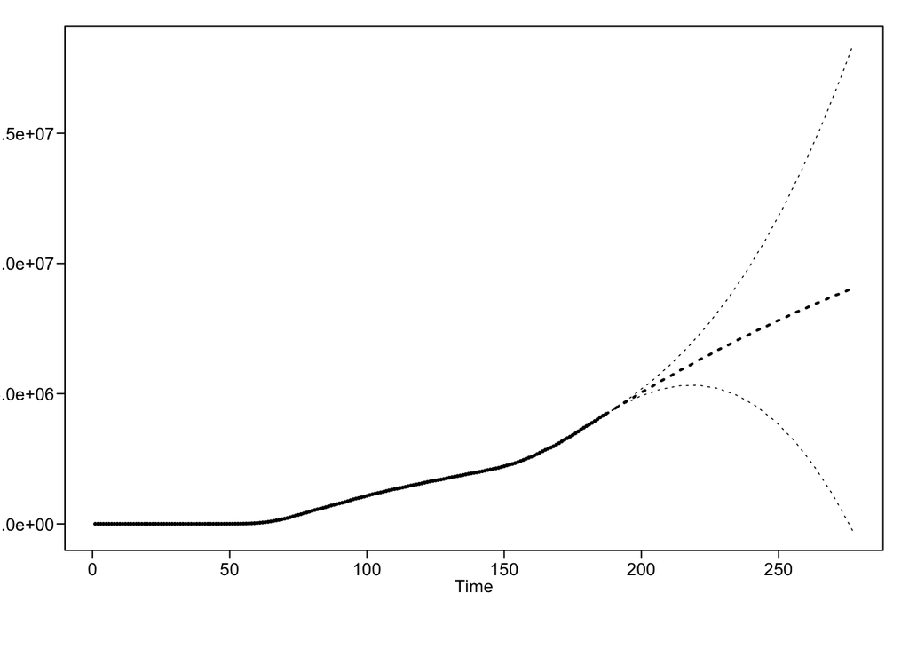

i. Plotting forecasts

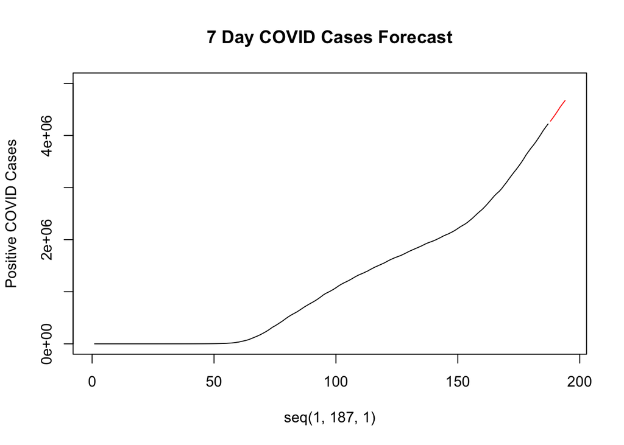

```r
plot(seq(1,187,1), us$positive, type = "l", xlim = c(0,195), ylim = c(0,5000000), ylab = "Positive COVID Cases", main = "7 Day COVID Cases Forecast")
lines(seq(188, 194,1), pos.preds7$f, type = "l", col = "red")
```

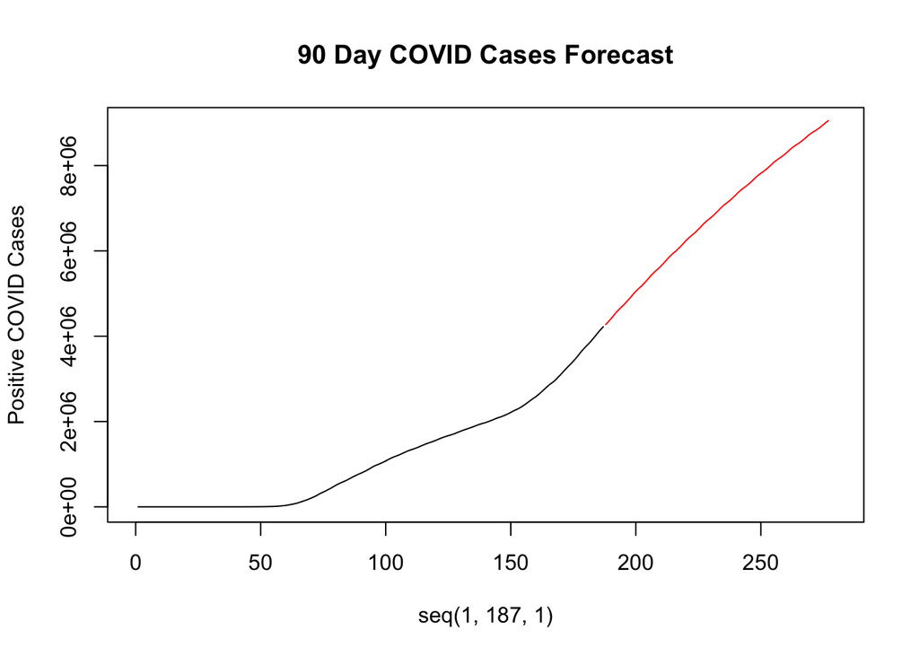

```r
plot(seq(1,187,1), us$positive, type = "l", xlim = c(0,280), ylim = c(0,9000000), ylab = "Positive COVID Cases", main = "90 Day COVID Cases Forecast")
lines(seq(188, 277,1), pos.preds90$f, type = "l", col = "red")
```

2. Forecast Increase Positive Cases
   1. Evaluation: Slowly dampening ACF and heavy wandering consistent with a (1-B) factor. As well as frequency peaks at 0 and .14. Consistent with (1-B) and seasonailty component of 7.

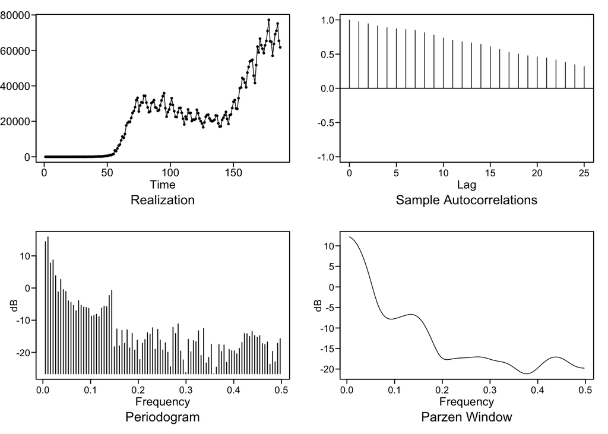

```
## $autplt
##  [1] 1.0000000 0.9740745 0.9439116 0.9109437 0.8869924 0.8711719 0.8605261
##  [8] 0.8462935 0.8144161 0.7772852 0.7356766 0.7045767 0.6829609 0.6646632
## [15] 0.6432819 0.6088202 0.5688872 0.5293417 0.5001353 0.4761589 0.4592724
## [22] 0.4426271 0.4148783 0.3789333 0.3458221 0.3182895
##
## $freq
##  [1] 0.005347594 0.010695187 0.016042781 0.021390374 0.026737968
##  [6] 0.032085561 0.037433155 0.042780749 0.048128342 0.053475936
## [11] 0.058823529 0.064171123 0.069518717 0.074866310 0.080213904
## [16] 0.085561497 0.090909091 0.096256684 0.101604278 0.106951872
## [21] 0.112299465 0.117647059 0.122994652 0.128342246 0.133689840
## [26] 0.139037433 0.144385027 0.149732620 0.155080214 0.160427807
## [31] 0.165775401 0.171122995 0.176470588 0.181818182 0.187165775
## [36] 0.192513369 0.197860963 0.203208556 0.208556150 0.213903743
```

[output cut: 53 more lines]

```
b. Differencing Data: much more stationary data and have surfaced a seasonaly component = 7 seen on ACF peaks at 7, 14, 21
```

```r
#a
plotts.sample.wge(us$positiveIncrease)
```

```r
#b
inpos.diff = artrans.wge(us$positiveIncrease, phi.tr = 1, lag.max = 100)
```

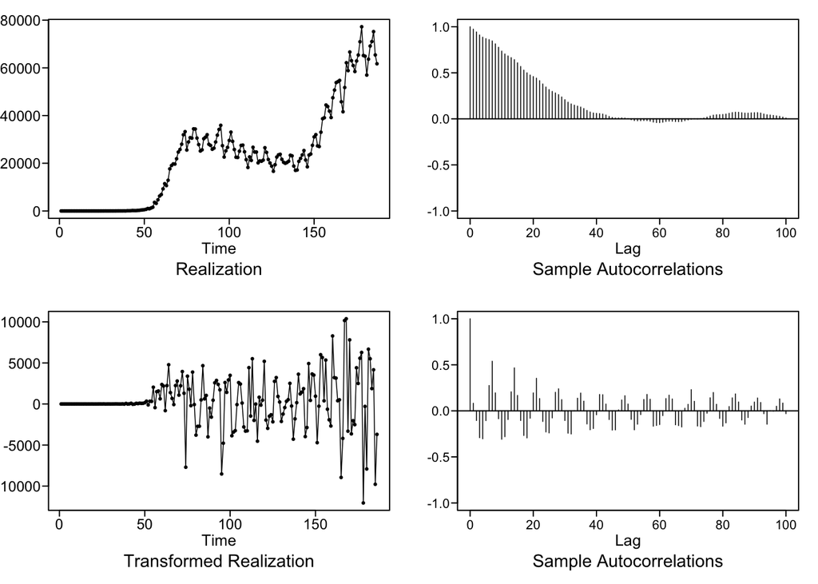

c. Seaonality Transformation: stationary data, and an ACF that reflects data other than whitenoise to be modeled.

```r
#c
inpos.diff.seas = artrans.wge(inpos.diff,phi.tr = c(0,0,0,0,0,0,1), lag.max = 100)
```

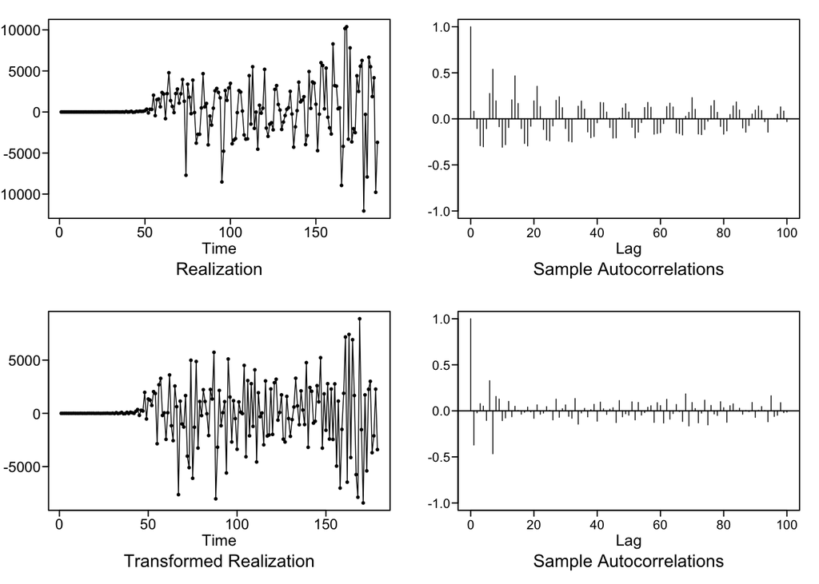

d. Model IDing: diagnose with aic.wge to determine phi, thetas: Both AIC/BIC select ARMA(4,2)

```r
#d
aic5.wge(inpos.diff.seas)
```

```
## ---------WORKING... PLEASE WAIT...
##
##
## Five Smallest Values of  aic
```

```
##       p    q        aic
## 15    4    2   15.62368
## 9     2    2   15.74701
## 18    5    2   15.74771
## 12    3    2   15.75351
## 7     2    0   15.75551
```

```r
aic5.wge(inpos.diff.seas, type = "bic")
```

```
## ---------WORKING... PLEASE WAIT...
##
##
## Five Smallest Values of  bic
```

```
##       p    q        bic
## 15    4    2   15.74832
## 2     0    1   15.79201
## 7     2    0   15.80893
## 4     1    0   15.81457
## 3     0    2   15.81522
```

```
e. White Noise Test: Reject the H_null and accept this data is not white noise
```

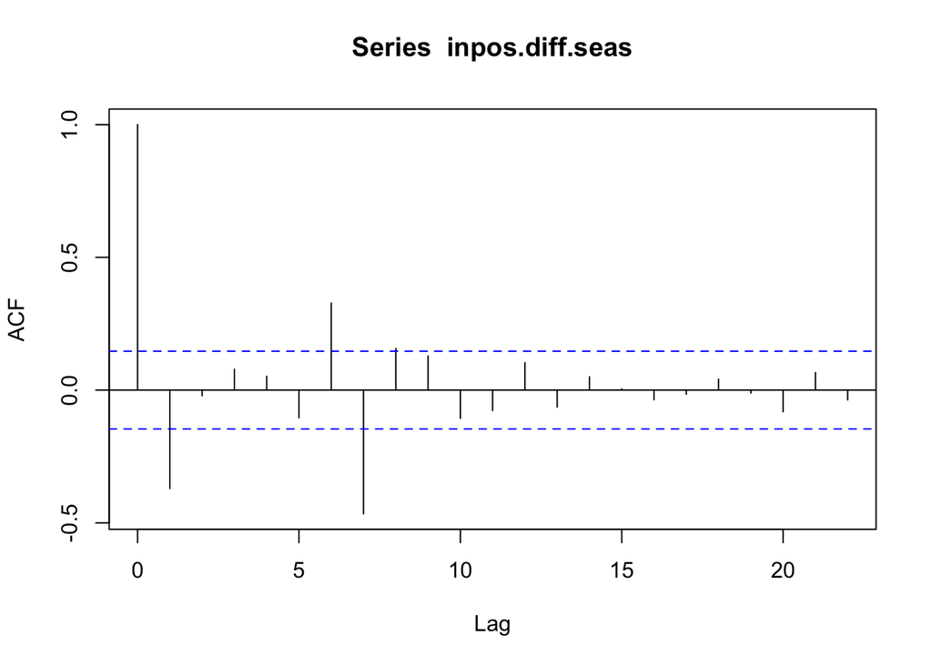

```r
#e
acf(inpos.diff.seas)
```

```r
ljung.wge(inpos.diff.seas)$pval
```

```
## Obs -0.3711871 -0.02127283 0.07854862 0.05194601 -0.1044838 0.3276797 -0.4658847 0.1565306 0.1284186 -0.1060791 -0.07693327 0.1030723 -0.06391648 0.05002847 0.004471288 -0.03640442 -0.01551996 0.04133725 -0.01110058 -0.08153895 0.06570572 -0.03709739 -0.02390062 0.04588417
```

```
## [1] 1.246447e-12
```

```
f. Estiamte Phis, Thetas:
g. Model Building
```

```r
#f
est.inpos.seas = est.arma.wge(inpos.diff.seas, p = 4, q = 2)
```

```
##
## Coefficients of Original polynomial:
## -1.8727 -1.4974 -0.4735 0.0283
##
## Factor                 Roots                Abs Recip    System Freq
## 1+1.1293B+0.6983B^2   -0.8086+-0.8822i      0.8357       0.3681
## 1+0.7944B             -1.2588               0.7944       0.5000
## 1-0.0510B              19.6244               0.0510       0.0000
##
##
```

```r
mean(us$positiveIncrease)
```

```
## [1] 22567.12
```

```r
#g
```

```
h. Forecast 7/90 Days
```

```r
#7 day
inpos.preds7 = fore.aruma.wge(us$positiveIncrease, phi = est.inpos.seas$phi, theta = est.inpos.seas$theta, d=1, s=7, n.ahead = 7)
```

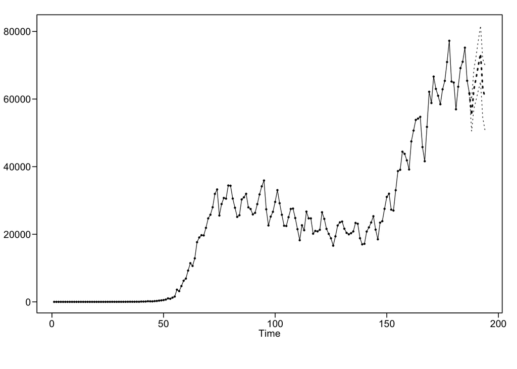

```r
#90 day
inpos.preds90 = fore.aruma.wge(us$positiveIncrease, phi = est.inpos.seas$phi, theta = est.inpos.seas$theta, d=1, s=7, n.ahead = 90)
```

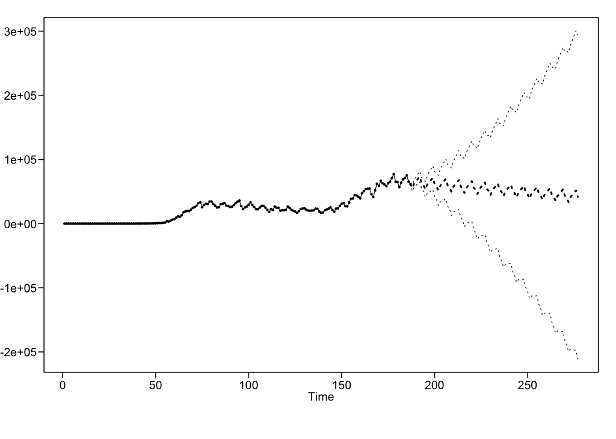

i. Plotting forecasts

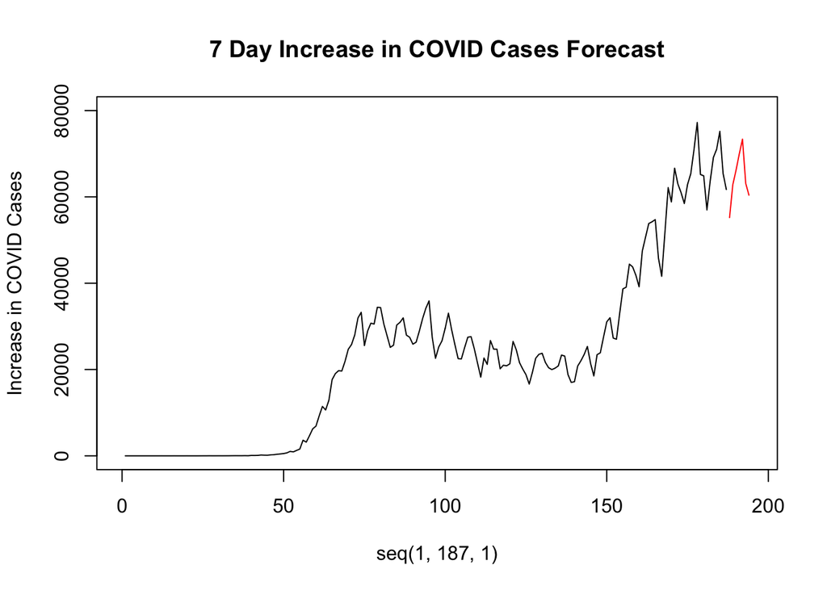

```r
#7 day forecast
plot(seq(1,187,1), us$positiveIncrease, type = "l", xlim = c(0,195), ylim = c(0,80000), ylab = "Increase in COVID Cases", main = "7 Day Increase in COVID Cases Forecast")
lines(seq(188, 194,1), inpos.preds7$f, type = "l", col = "red")
```

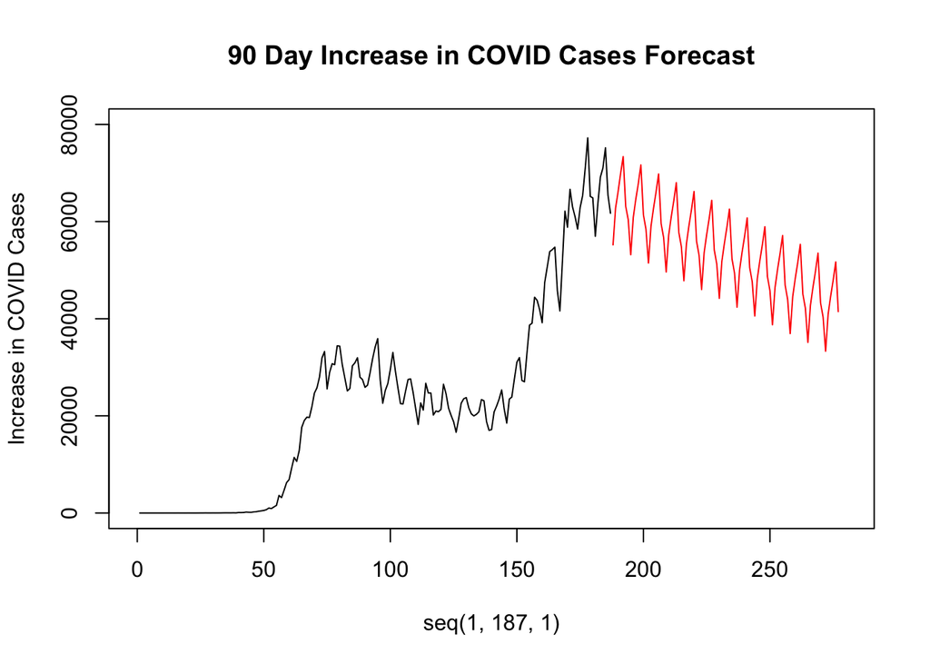

```r
#90 day forecast
plot(seq(1,187,1), us$positiveIncrease, type = "l", xlim = c(0,280), ylim = c(0,80000), ylab = "Increase in COVID Cases", main = "90 Day Increase in COVID Cases Forecast")
lines(seq(188, 277,1), inpos.preds90$f, type = "l", col = "red")
```

#### Forecast Currently Hospitalized Patients using Positive Increase and Total Cases

##### MLR w/ Correlated Errors w/ No Lagged Variables

1. Fit simple regression model predicting *hospitalizedCurrently* with *positive*, *positiveIncrease* and a trend.

```r
us.mlr.fit = lm(hospitalizedCurrently~positiveIncrease+positive+date, data=us)
summary(us.mlr.fit)
```

```
##
## Call:
## lm(formula = hospitalizedCurrently ~ positiveIncrease + positive +
##     date, data = us)
##
## Residuals:
##      Min       1Q   Median       3Q      Max
## -21825.6  -9253.8   -426.3   8552.6  24559.2
##
## Coefficients:
##                    Estimate Std. Error t value Pr(>|t|)
## (Intercept)      -6.090e+06  9.915e+05  -6.142 4.96e-09 ***
## positiveIncrease  9.013e-01  9.757e-02   9.237  < 2e-16 ***
## positive         -1.452e-02  2.546e-03  -5.703 4.64e-08 ***
## date              3.327e+02  5.411e+01   6.149 4.76e-09 ***
## ---
## Signif. codes:  0 '***' 0.001 '**' 0.01 '*' 0.05 '.' 0.1 ' ' 1
##
## Residual standard error: 12220 on 183 degrees of freedom
## Multiple R-squared:  0.7136, Adjusted R-squared:  0.7089
## F-statistic:   152 on 3 and 183 DF,  p-value: < 2.2e-16
```

```r
us.mlr.phi= aic.wge(us.mlr.fit$residuals, p = 0:12, q = 0:12)
us.mlr.phi
```

```
## $type
## [1] "aic"
##
## $value
## [1] 15.33178
##
## $p
## [1] 8
##
## $q
## [1] 6
##
## $phi
## [1]  1.42405076 -0.24799231 -0.61685924  0.06377608  0.97333749 -0.77347228
## [7]  0.41766520 -0.27190429
##
## $theta
## [1]  0.6015312  0.1219283 -0.4916272 -0.4838232  0.7755189 -0.4855814
##
## $vara
## [1] 3880013
```

```r
#us.mlr.modelfit = arima(us$hospitalizedCurrently, order = c(8,0,6), xreg = cbind(us$positive, us$hospitalizedIncrease, us$date))
#AIC(us.mlr.modelfit)

#fit = arima(CM$cmort,order = c(phi$p,0,phi$q), seasonal = list(order = c(1,0,0), period = 52), xreg = cbind(CM$temp, CM$part, CM$Week))

#AIC(fit) #3166
```

```r
#acf(us.mlr.modelfit$residuals) #Visual ACF test
#us.mlr.wn.test = ljung.wge(us.mlr.modelfit$residuals)
#us.mlr.wn.test$pval
```

5. Load the forecasted positive and increase positive in a data frame

```r
#7 forecast
#regressions7 = data.frame(positiveIncrease = inpos.preds7$f, positive = pos.preds7$f, date = seq(188,194,1))
```

```r
#90 forecast
#regressions90 = data.frame(positiveIncrease = inpos.preds90$f, positive = pos.preds90$f, date = seq(188,277,1))
```

```r
#7 day predictions
#us7 = predict(us.mlr.modelfit, newxreg = regressions7)
```

```r
#90 day predictions
#us90 = predict(us.mlr.modelfit, newxreg = regressions90)
```

```r
#plot(seq(1,187,1), us$hospitalizedCurrently, type = "l", xlim = c(0,195), ylim = c(0,475000), ylab = "Currently Hospitalized COVID Cases", main = "7 Day Forecast for COVID Hospitalized Cases")
#lines(seq(188,194,1), us7$pred, type = "l", col = "red")
```

```r
#usSmall = us[1:150,]
#us.ksfit = lm(hospitalizedCurrently~positive+)


#EXAMPLE CODE
#Find ASE  Need to forecast last 30 of known series.
#CMsmall = CM[1:478,]
#ksfit = lm(cmort~temp+part+Week, data = CMsmall)
#phi = aic.wge(ksfit$residuals)
#fit = arima(CMsmall$cmort,order = c(phi$p,0,0), seasonal = list(order = c(1,0,0), period = 52), xreg = cbind(CMsmall$temp, CMsmall$part, CMsmall$Week))

#AIC(fit) #2990.101

#last30 = data.frame(temp = CM$temp[479:508], part = CM$part[479:508], CMWeek = seq(479,508,1))
#get predictions
#predsCMort = predict(fit,newxreg = last30)

#ASE = mean((CM$cmort[479:508] - predsCMort$pred)^2)
#ASE #84.2398

#plot(seq(1,508,1), CM$cmort, type = "l",xlim = c(0,528), ylab = "Cardiac Mortality", main = "Last 30 Week Cardiac Mortality Forecast")
#lines(seq(479,508,1), predsCMort$pred, type = "l", col = "red")
```

#### VAR Model

1. Creating train / test data

```r
library(vars)
usTrain.var = us[1:122,]
usTrain.var
```

[output not shown]

[output cut: 600 more lines]

2. Fit VAR mode

```r
us.var.fit = VAR(cbind(usTrain.var$hospitalizedCurrently, usTrain.var$positive, usTrain.var$positiveIncrease), lag.max = 14, type = "both")
```

3. Predictions

```r
pred.var = predict(us.var.fit, n.ahead = 10)
```

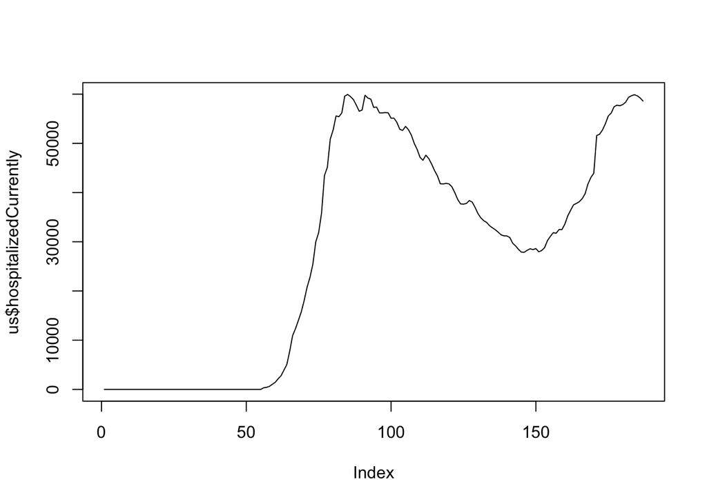

```r
plot(us$hospitalizedCurrently, type = "l")
lines(seq(123,132,1),pred.var$fcst$y1[,1],col="red")
```

```r
varASE = mean((us$hospitalizedCurrently[123:132]-pred.var$fcst$y1[1:10])^2)
varASE
```

```
## [1] NA
```